# 2-r-intermed-cn

## 1. Boolean 逻辑判断

### Equality 等效逻辑判断

R用`==`用来判别其左右两边的语句是否等价，如果等价，返回逻辑值`TRUE`, 否则返回`FALSE`

```r
# Comparison of logicals
TRUE == FALSE

# Comparison of numerics
-6 * 14 != 17 - 101

# Comparison of character strings
"useR" == "user"

# Compare a logical with a numeric
TRUE == 1
```

FALSE

FALSE

FALSE

TRUE

因为 `TRUE` 在底层被赋值为1, 所以`TRUE == 1` 被判断为 `TRUE`. 请注意`==` 和 `=`的不同。一个是比较，一个是赋值，虽然我们在R里面通常用 `<-` 来赋值。

### Greater and less than 大于和小于

这里我们介绍大于`>`和小于 `<`, 你可以添加`=` 来表示 大于等于或者小于等于。看看下面的例子，脑补一下出来的逻辑判断是什么？

- (1 + 2) > 4
- "dog" < "Cats"
- TRUE <= FALSE

R基于字母表的顺序对字符串进行比较。

```r
# Comparison of numerics
-6 * 5 + 2 >= -10 + 1

# Comparison of character strings
"raining" <= "raining dogs"

# Comparison of logicals
TRUE > FALSE
```

FALSE

TRUE

TRUE

### 比较向量 Compare vectors

R 对于向量的处理是非常在行的，不用额外的修改，R就能执行向量有关的操作。

下面的示例代码给出了两个向量，一个是weibo, 一个是twitter。每一个向量记录了过去7天，你的页面被浏览的次数。

小练习： 使用关系运算符（relational operators）, 找到逻辑判断答案, i.e. TRUE or FALSE, 问题如下:

- 哪些天你的微博被浏览次数超过 16?
- 哪些天你的微博浏览次数低于10?
- 哪些天你的微博浏览次数超过twitter？

```r
# The weibo and twitter vectors have already been created for you
weibo <- c(15, 9, 13, 6, 7, 14, 14)
twitter <- c(20, 7, 6, 16, 9, 13, 14)

# Popular days
weibo > 16
```

1. FALSE

2. FALSE

3. FALSE

4. FALSE

5. FALSE

6. FALSE

7. FALSE

```r
# Quiet days
weibo <= 10
```

1. FALSE

2. TRUE

3. FALSE

4. TRUE

5. TRUE

6. FALSE

7. FALSE

```r
# weibo more popular than twitter
weibo > twitter
```

1. FALSE

2. TRUE

3. TRUE

4. FALSE

5. FALSE

6. TRUE

7. FALSE

### 比较矩阵Compare matrices

R 可以处理各种不同的数据结构，自然也包括矩阵。

这一次 weibo 和 twitter被存储在一个叫做views的矩阵里面。 第一行包含 weibo 的浏览量; 第二行是 twitter 的， twitter and weibo 的原始向量也都在。

小练习：

```r
# The social data has been created for you
weibo <- c(16, 9, 13, 5, 2, 17, 14)
twitter <- c(17, 7, 5, 16, 8, 13, 14)
views <- matrix(c(weibo, twitter), nrow = 2, byrow = TRUE)
views
```

| 16 | 9 | 13 | 5 | 2 | 17 | 14 |
| --- | --- | --- | --- | --- | --- | --- |
| 17 | 7 | 5 | 16 | 8 | 13 | 14 |

```r
# When does views equal 13?
views == 6
```

| FALSE | FALSE | FALSE | FALSE | FALSE | FALSE | FALSE |
| --- | --- | --- | --- | --- | --- | --- |
| FALSE | FALSE | FALSE | FALSE | FALSE | FALSE | FALSE |

```r
# When is views less than or equal to 14?
views <= 5
```

| FALSE | FALSE | FALSE | TRUE | TRUE | FALSE | FALSE |
| --- | --- | --- | --- | --- | --- | --- |
| FALSE | FALSE | TRUE | FALSE | FALSE | FALSE | FALSE |

### & and |

下面这些表达式的结果都是 TRUE:

- TRUE & TRUE
- FALSE | TRUE
- 5 <= 5 & 2 < 3
- 3 < 4 | 7 < 6

特别注意， 3 < x < 7 不能用来检测 x 是否在 3 and 7 之间; 要达到这个比较的目的，你需要使用 3 < x & x < 7。

在下面的小练习里，你将使用last这个变量，你最后一天weibo的浏览量。

- 最后一天的浏览量是小于5还是大于10?
- 最后一天的浏览量是在15到20之间么（左开右闭区间）?

```r
# The weibo and last variable are already defined for you
weibo <- c(16, 9, 13, 5, 2, 17, 14)
last <- tail(weibo, 1)
last
```

14

```r
# Is last under 5 or above 10?
last < 5 | last > 10
```

TRUE

```r
# Is last between 15 (exclusive) and 20 (inclusive)?
last > 15 & last <= 20
```

FALSE

## 2. Conditional statements

### if statement

```r
# Variables related to your last day of recordings
medium <- "weibo"
num_views <- 14

# Examine the if statement for medium
if (medium == "weibo") {
print("Showing weibo information")
}
```

```
[1] "Showing weibo information"
```

```r
# Write the if statement for num_views
if (num_views > 15) {
print("You're popular!")
}
```

```r
# Variables related to your last day of recordings
medium <- "weibo"
num_views <- 14

# Control structure for medium
if (medium == "weibo") {
print("Showing weibo information")
} else{
print("Unknown medium")
}
```

```
[1] "Showing weibo information"
```

```r
# Control structure for num_views
if (num_views > 15) {
print("You're popular!")
} else {
print("Try to be more visible!")
}
```

```
[1] "Try to be more visible!"
```

```r
# Variables related to your last day of recordings
medium <- "twitter"
num_views <- 14

# Control structure for medium
if (medium == "weibo") {
print("Showing weibo information")
} else if (medium == "twitter") {
# Add code to print correct string when condition is TRUE
print("Showing twitter information")
} else {
print("Unknown medium")
}
```

```
[1] "Showing twitter information"
```

```r
# Variables related to your last day of recordings
medium <- "weibo"
num_views <- 14

# Control structure for medium
if (medium == "weibo") {
print("Showing weibo information")
} else if (medium == "twitter") {
# Add code to print correct string when condition is TRUE
print("Showing twitter information")
} else {
print("Unknown medium")
}
```

```
[1] "Showing weibo information"
```

```r
# Variables related to your last day of recordings
li <- 15
fb <- 9

# Code the control-flow construct
if (li >= 15 & fb >= 15) {
sms <- 2 * (li + fb)
} else if (li < 10 & fb < 10) {
sms <- 0.5 * (li + fb)
} else {
sms <- li + fb
}

# Print the resulting sms to the console
print(sms)
```

```
[1] 24
```

## 3. while loop

```r
# Initialize the speed variable
speed <- 64

# Code the while loop
while (speed > 30) {
  print("Slow down!")
  speed <- speed - 7
}

# Print out the speed variable
speed
```

```
[1] "Slow down!"
[1] "Slow down!"
[1] "Slow down!"
[1] "Slow down!"
[1] "Slow down!"
```

29

```r
# Initialize the speed variable
speed <- 64

# Extend/adapt the while loop
while (speed > 30) {
  print(paste("Your speed is", speed))
  if (speed > 48) {
    print("Slow down big time!")
    speed <- speed - 11
  } else {
    print("Slow down!")
    speed <- speed - 6
  }
}
```

```
[1] "Your speed is 64"
[1] "Slow down big time!"
[1] "Your speed is 53"
[1] "Slow down big time!"
[1] "Your speed is 42"
[1] "Slow down!"
[1] "Your speed is 36"
[1] "Slow down!"
```

### Stop the while loop: break

Remember that the break statement is a control statement. When R encounters it, the while loop is abandoned completely.

```r
# Initialize the speed variable
speed <- 88

while (speed > 30) {
  print(paste("Your speed is", speed))

  # Break the while loop when speed exceeds 80
  if ( speed > 80) {
    break
  }

  if (speed > 48) {
    print("Slow down big time!")
    speed <- speed - 11
  } else {
    print("Slow down!")
    speed <- speed - 6
  }
}
```

```
[1] "Your speed is 88"
```

### build a while loop from scratch

```r
# Initialize i as 1
i <- 1

# Code the while loop
while (i <= 10) {
  print(3 * i)
  if ( (3 * i) %% 8 == 0  ) {
    print(3 * i)
    break
  }
  i <- i + 1
}
```

```
[1] 3
[1] 6
[1] 9
[1] 12
[1] 15
[1] 18
[1] 21
[1] 24
[1] 24
```

### Loop over a vector

```r
# The linkedin vector has already been defined for you
linkedin <- c(16, 9, 13, 5, 2, 17, 14)

# Loop version 1
for (lin in linkedin) {
  print(lin)
}
```

```
[1] 16
[1] 9
[1] 13
[1] 5
[1] 2
[1] 17
[1] 14
```

```r
# Loop version 2
for(i in 1:length(linkedin)){
  print(linkedin[i])
  }
```

```
[1] 16
[1] 9
[1] 13
[1] 5
[1] 2
[1] 17
[1] 14
```

### Loop over a list

```r
# The nyc list is already specified
nyc <- list(pop = 8405837,
            boroughs = c("Manhattan", "Bronx", "Brooklyn", "Queens", "Staten Island"),
            capital = FALSE)

# Loop version 1
for(n in nyc){
  print(n)
}
```

```
[1] 8405837
[1] "Manhattan"     "Bronx"         "Brooklyn"      "Queens"
[5] "Staten Island"
[1] FALSE
```

```r
# Loop version 2
for(i in 1:length(nyc)){
  print(nyc[[i]])
}
```

```
[1] 8405837
[1] "Manhattan"     "Bronx"         "Brooklyn"      "Queens"
[5] "Staten Island"
[1] FALSE
```

### Loop over a matrix

```r
ttt<-matrix(c("O",NA,"X",NA,"O","O","X",NA,"X"), nrow=3, byrow=TRUE)
ttt
```

| O | NA | X |
| --- | --- | --- |
| NA | O | O |
| X | NA | X |

```r
# define the double for loop
for (i in 1:nrow(ttt)) {
  for (j in 1:ncol(ttt)) {
    print(paste("On row", i, "and column", j, "the board contains", ttt[i,j]))
  }
}
```

```
[1] "On row 1 and column 1 the board contains O"
[1] "On row 1 and column 2 the board contains NA"
[1] "On row 1 and column 3 the board contains X"
[1] "On row 2 and column 1 the board contains NA"
[1] "On row 2 and column 2 the board contains O"
[1] "On row 2 and column 3 the board contains O"
[1] "On row 3 and column 1 the board contains X"
[1] "On row 3 and column 2 the board contains NA"
[1] "On row 3 and column 3 the board contains X"
```

```r
# The linkedin vector has already been defined for you
linkedin <- c(16, 9, 13, 5, 2, 17, 14)

# Extend the for loop
for (li in linkedin) {
  if (li > 10) {
    print("You're popular!")
  } else {
    print("Be more visible!")
  }

  # Add if statement with break
  if (li > 16){
  print("This is ridiculous, I'm outta here!")
  }
  # Add if statement with next
  if (li < 5){
    print("This is too embarrassing!")
    next
  }

  print(li)
}
```

```
[1] "You're popular!"
[1] 16
[1] "Be more visible!"
[1] 9
[1] "You're popular!"
[1] 13
[1] "Be more visible!"
[1] 5
[1] "Be more visible!"
[1] "This is too embarrassing!"
[1] "You're popular!"
[1] "This is ridiculous, I'm outta here!"
[1] 17
[1] "You're popular!"
[1] 14
```

### Build a for loop from scratch

```r
# Pre-defined variables
rquote <- "r's internals are irrefutably intriguing"
chars <- strsplit(rquote, split = "")[[1]]

# Initialize rcount
rcount <- 0

# Finish the for loop
for (char in chars) {
  if(char == "r")
rcount = rcount + 1
if(char == "u")
  break
}

# Print out rcount
print(rcount)
```

```
[1] 5
```

## 4. Function

```r
?mean
help(mean)
```

```r
# Inspect the arguments of the mean() function
args(mean)
```

```
function (x, ...)
NULL
```

```r
# The linkedin and facebook vectors have already been created for you
linkedin <- c(16, 9, 13, 5, 2, 17, 14)
facebook <- c(17, 7, 5, 16, 8, 13, 14)

# Calculate average number of views
avg_li <- mean(x = linkedin)
avg_fb <- mean(facebook)


# Inspect avg_li and avg_fb
avg_li
avg_fb
```

10.8571428571429

11.4285714285714

```r
linkedin + facebook
```

1. 33

2. 16

3. 18

4. 21

5. 10

6. 30

7. 28

```r
# The linkedin and facebook vectors have already been created for you
linkedin <- c(16, 9, 13, 5, 2, 17, 14)
facebook <- c(17, 7, 5, 16, 8, 13, 14)

# Calculate the mean of the sum
avg_sum <- mean(linkedin + facebook)

# Calculate the trimmed mean of the sum
avg_sum_trimmed <- mean(x= (linkedin + facebook), trim = 0.2)

# Inspect both new variables
avg_sum
avg_sum_trimmed
```

22.2857142857143

22.6

When the trim argument is not zero, it chops off a fraction (equal to trim) of the vector you pass as argument x.

```r
# The linkedin and facebook vectors have already been created for you
linkedin <- c(16, 9, 13, 5, NA, 17, 14)
facebook <- c(17, NA, 5, 16, 8, 13, 14)

# Basic average of linkedin
mean(linkedin)

# Advanced average of linkedin
mean(linkedin, na.rm = TRUE)
```

<NA>

12.3333333333333

```r
# The linkedin and facebook vectors have already been created for you
linkedin <- c(16, 9, 13, 5, NA, 17, 14)
facebook <- c(17, NA, 5, 16, 8, 13, 14)

# Calculate the mean absolute deviation
mean(abs(linkedin - facebook), na.rm = TRUE)
```

4.8

### Create a function

```r
# Create a function pow_two()
pow_two <- function(a){
 a^2
}

# Use the function
pow_two(12)
```

144

```r
# Create a function sum_abs()
sum_abs <- function(a, b){
  abs(a) + abs(b)
}

# Use the function
sum_abs(-2, 3)
```

5

```r
hello <- function(){
 print("Hi there!")
  return(TRUE)
}


# Call the function hello()
hello()
```

```
[1] "Hi there!"
```

TRUE

```r
# Finish the pow_two() function
pow_two <- function(x, print_info=TRUE) {
  y <- x ^ 2
  if(print_info == TRUE){
  print(paste(x, "to the power two equals", y))
  }
  return(y)
}

pow_two(100, TRUE)
```

```
[1] "100 to the power two equals 10000"
```

10000

```r
linkedin <- c(16, 9, 13, 5, 5, 17, 14)
facebook <- c(17, 40, 5, 16, 8, 13, 14)
# Define the interpret function
interpret <- function(num_views) {
  if (num_views > 15) {
     print("You're popular!")
     return(num_views)
  } else {
    print("Try to be more visible!")
    return(0)
  }
}

# Call the interpret function twice
interpret(linkedin)
interpret(facebook[2])
```

```
[1] "You're popular!"
```

1. 16

2. 9

3. 13

4. 5

5. 5

6. 17

7. 14

```
[1] "You're popular!"
```

40

```r
# The linkedin and facebook vectors have already been created for you
linkedin <- c(16, 9, 13, 5, 2, 17, 14)
facebook <- c(17, 7, 5, 16, 8, 13, 14)

# The interpret() can be used inside interpret_all()
interpret <- function(num_views) {
  if (num_views > 15) {
    print("You're popular!")
    return(num_views)
  } else {
    print("Try to be more visible!")
    return(0)
  }
}

# Define the interpret_all() function
# views: vector with data to interpret
# return_sum: return total number of views on popular days
interpret_all <- function(views, return_sum=TRUE) {
  count <- 0
  for (v in views) {
  count <- count + interpret(v)

  }
  if (return_sum == TRUE) {
     return(count)
  } else {
    return(NULL)
  }
}
```

```r
# Call the interpret_all() function on both linkedin and facebook
interpret_all(linkedin)
interpret_all(facebook)
```

```
[1] "You're popular!"
[1] "Try to be more visible!"
[1] "Try to be more visible!"
[1] "Try to be more visible!"
[1] "Try to be more visible!"
[1] "You're popular!"
[1] "Try to be more visible!"
```

33

```
[1] "You're popular!"
[1] "Try to be more visible!"
[1] "Try to be more visible!"
[1] "You're popular!"
[1] "Try to be more visible!"
[1] "Try to be more visible!"
[1] "Try to be more visible!"
```

33

```r
# Check out the currently attached packages again
search()
```

1. '.GlobalEnv'

2. 'jupyter:irkernel'

3. 'package:stats'

4. 'package:graphics'

5. 'package:grDevices'

6. 'package:utils'

7. 'package:datasets'

8. 'package:methods'

9. 'Autoloads'

10. 'package:base'

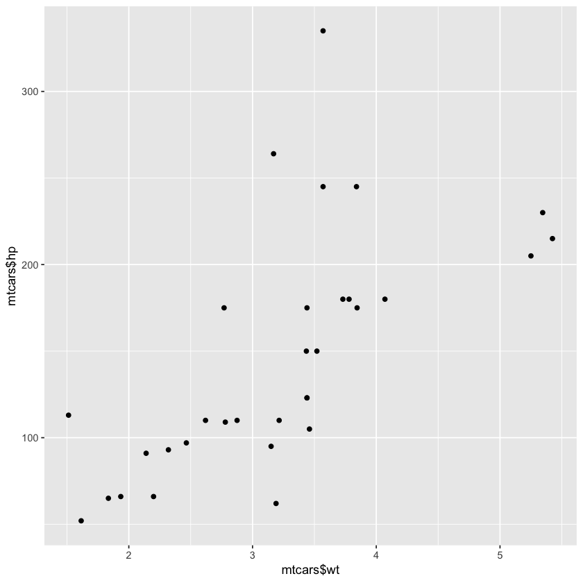

```r
# Load the ggplot2 package
library(ggplot2)

# Retry the qplot() function
qplot(mtcars$wt, mtcars$hp)
```

## 5. apply family

### lapply and anonymous functions

```r
# Definition of split_low
pioneers <- c("GAUSS:1777", "BAYES:1702", "PASCAL:1623", "PEARSON:1857")
split <- strsplit(pioneers, split = ":")
split_low <- lapply(split, tolower)
split_low
```

1. 1. 'gauss'

   2. '1777'

2. 1. 'bayes'

   2. '1702'

3. 1. 'pascal'

   2. '1623'

4. 1. 'pearson'

   2. '1857'

```r
# Transform: use anonymous function inside lapply
names <- lapply(split_low, function(x) {x[1]}  )
names
# Transform: use anonymous function inside lapply
 years <- lapply(split_low, function(x) {x[2]})
years
```

1. 'gauss'

2. 'bayes'

3. 'pascal'

4. 'pearson'

1. '1777'

2. '1702'

3. '1623'

4. '1857'

### Use lapply with additional arguments

```r
# Definition of split_low
pioneers <- c("GAUSS:1777", "BAYES:1702", "PASCAL:1623", "PEARSON:1857")
split <- strsplit(pioneers, split = ":")
split_low <- lapply(split, tolower)

# Generic select function
select_el <- function(x, index) {
  x[index]
}

# Use lapply() twice on split_low: names and years
names <- lapply(split_low, select_el, index = 1)
names
years <- lapply(split_low, select_el, index = 2)
years
```

1. 'gauss'

2. 'bayes'

3. 'pascal'

4. 'pearson'

1. '1777'

2. '1702'

3. '1623'

4. '1857'

### How to use sapply

```r
temp<-list(c(3,7,9,6,-1),c(6,9,12,13,5),c(4,8,3,-1,-3),c(1,4,7,2,-2),c(5,7,9,4,2),c(-3,5,8,9,4),c(3,6,9,4,1))
# Use lapply() to find each day's minimum temperature
lapply(temp, min)
```

1. -1

2. 5

3. -3

4. -2

5. 2

6. -3

7. 1

```r
# Use sapply() to find each day's minimum temperature
sapply(temp, min)
```

1. -1

2. 5

3. -3

4. -2

5. 2

6. -3

7. 1

```r
# Use lapply() to find each day's maximum temperature
lapply(temp, max)
```

1. 9

2. 13

3. 8

4. 7

5. 9

6. 9

7. 9

```r
# Use sapply() to find each day's maximum temperature
sapply(temp, max)
```

1. 9

2. 13

3. 8

4. 7

5. 9

6. 9

7. 9

### sapply with your own function

```r
extremes_avg <- function(x) {
  ( min(x) + max(x) ) / 2
}

# Apply extremes_avg() over temp using sapply()
sapply(temp, extremes_avg)
```

1. 4

2. 9

3. 2.5

4. 2.5

5. 5.5

6. 3

7. 5

```r
# Apply extremes_avg() over temp using lapply()
lapply(temp, extremes_avg)
```

1. 4

2. 9

3. 2.5

4. 2.5

5. 5.5

6. 3

7. 5

### sapply with function returning vector

```r
# Create a function that returns min and max of a vector: extremes
extremes <- function(x) {
  c(min = min(x), max = max(x))
}

# Apply extremes() over temp with sapply()
sapply(temp, extremes)
```

| min | -1 | 5 | -3 | -2 | 2 | -3 | 1 |
| --- | --- | --- | --- | --- | --- | --- | --- |
| max | 9 | 13 | 8 | 7 | 9 | 9 | 9 |

```r
# Apply extremes() over temp with lapply()
lapply(temp, extremes)
```

1. **min**

   -1

   **max**

   9

2. **min**

   5

   **max**

   13

3. **min**

   -3

   **max**

   8

4. **min**

   -2

   **max**

   7

5. **min**

   2

   **max**

   9

6. **min**

   -3

   **max**

   9

7. **min**

   1

   **max**

   9

### sapply can't simplify, now what?

```r
# Definition of below_zero()
below_zero <- function(x) {
  return(x[x < 0])
}

# Apply below_zero over temp using sapply(): freezing_s
freezing_s <- sapply(temp, below_zero)
freezing_s
```

1. -1

3. 1. -1

   2. -3

4. -2

6. -3

```r
# Apply below_zero over temp using lapply(): freezing_l
freezing_l <- lapply(temp, below_zero)
freezing_l
```

1. -1

3. 1. -1

   2. -3

4. -2

6. -3

```r
# Are freezing_s and freezing_l identical?
identical(freezing_s, freezing_l)
```

TRUE

### sapply with functions that return NULL

```r
# Definition of print_info()
print_info <- function(x) {
  cat("The average temperature is", mean(x), "\n")
}
```

```r
# Apply print_info() over temp using sapply()
sapply(temp, print_info)
```

```
The average temperature is 4.8
The average temperature is 9
The average temperature is 2.2
The average temperature is 2.4
The average temperature is 5.4
The average temperature is 4.6
The average temperature is 4.6
```

1. NULL

2. NULL

3. NULL

4. NULL

5. NULL

6. NULL

7. NULL

```r
# Apply print_info() over temp using lapply()
lapply(temp, print_info)
```

```
The average temperature is 4.8
The average temperature is 9
The average temperature is 2.2
The average temperature is 2.4
The average temperature is 5.4
The average temperature is 4.6
The average temperature is 4.6
```

1. NULL

2. NULL

3. NULL

4. NULL

5. NULL

6. NULL

7. NULL

Notice here that, quite surprisingly, sapply() does not simplify the list of NULL's. That's because the 'vector-version' of a list of NULL's would simply be a NULL, which is no longer a vector with the same length as the input. Proceed to the next exercise.

### Use vapply

vapply() can be considered a more robust version of sapply(), because you explicitly restrict the output of the function you want to apply.

```r
# Definition of basics()
basics <- function(x) {
  c(min = min(x), mean = mean(x), max = max(x))
}

# Apply basics() over temp using vapply()
vapply(temp, basics, numeric(3))
```

| min | -1.0 | 5 | -3.0 | -2.0 | 2.0 | -3.0 | 1.0 |
| --- | --- | --- | --- | --- | --- | --- | --- |
| mean | 4.8 | 9 | 2.2 | 2.4 | 5.4 | 4.6 | 4.6 |
| max | 9.0 | 13 | 8.0 | 7.0 | 9.0 | 9.0 | 9.0 |

```r
sapply(temp, max)
vapply(temp, max, numeric(1))
```

1. 9

2. 13

3. 8

4. 7

5. 9

6. 9

7. 9

1. 9

2. 13

3. 8

4. 7

5. 9

6. 9

7. 9

```r
# Convert to vapply() expression
sapply(temp, function(x, y) { mean(x) > y }, y = 5)
vapply(temp, function(x, y) { mean(x) > y }, y = 5, logical(1))
```

1. FALSE

2. TRUE

3. FALSE

4. FALSE

5. TRUE

6. FALSE

7. FALSE

1. FALSE

2. TRUE

3. FALSE

4. FALSE

5. TRUE

6. FALSE

7. FALSE

## 6. Some important functions

```r
errors <- c(1.9, -2.6, 4.0, -9.5, -3.4, 7.3)

# Sum of absolute rounded values of errors
sum(round(abs(errors)))
```

29

### Data Utilities

R features a bunch of functions to juggle around with data structures:

- `seq()`: Generate sequences, by specifying the from, to, and by arguments.
- `rep()`: Replicate elements of vectors and lists.
- `sort()`: Sort a vector in ascending order. Works on numerics, but also on character strings and logicals.
- `rev()`: Reverse the elements in a data structures for which reversal is defined.
- `str()`: Display the structure of any R object.
- `append()`: Merge vectors or lists.
- `is.*()`: Check for the class of an R object.
- `as.*()`: Convert an R object from one class to another.
- `unlist()`: Flatten (possibly embedded) lists to produce a vector.

```r
linkedin <- list(16, 9, 13, 5, 2, 17, 14)
facebook <- list(17, 7, 5, 16, 8, 13, 14)

# Convert linkedin and facebook to a vector: li_vec and fb_vec
li_vec <- unlist(linkedin)
li_vec
```

1. 16

2. 9

3. 13

4. 5

5. 2

6. 17

7. 14

```r
fb_vec <- unlist(facebook)
# Append fb_vec to li_vec: social_vec
social_vec <- append(li_vec, fb_vec)

# Sort social_vec
sort(social_vec, decreasing = TRUE)
```

1. 17

2. 17

3. 16

4. 16

5. 14

6. 14

7. 13

8. 13

9. 9

10. 8

11. 7

12. 5

13. 5

14. 2

```r
rep(seq(1, 7, by = 2), times = 7)
```

[output not shown]

```r
# Create first sequence: seq1
seq1 <- seq(1, 500, by = 3)

# Create second sequence: seq2
seq2 <- seq(1200, 900, by = -7)
```

```r
# Calculate total sum of the sequences
sum(c(seq1, seq2))
```

87029

### grepl & grep

In their most basic form, regular expressions can be used to see whether a pattern exists inside a character string or a vector of character strings. For this purpose, you can use:

- `grepl()`, which returns TRUE when a pattern is found in the corresponding character string.
- `grep()`, which returns a vector of indices of the character strings that contains the pattern.

```r
# The emails vector has already been defined for you
emails <- c("john.doe@ivyleague.edu", "education@world.gov", "dalai.lama@peace.org",
            "invalid.edu", "quant@bigdatacollege.edu", "cookie.monster@sesame.tv")

# Use grepl() to match for "edu"
grepl("edu", emails)
```

1. TRUE

2. TRUE

3. FALSE

4. TRUE

5. TRUE

6. FALSE

```r
grep("edu", emails)
```

1. 1

2. 2

3. 4

4. 5

```r
# Use grep() to match for "edu", save result to hits
hits <- grep("edu", emails)

# Subset emails using hits
emails[hits]
```

1. 'john.doe@ivyleague.edu'

2. 'education@world.gov'

3. 'invalid.edu'

4. 'quant@bigdatacollege.edu'

- You can use the caret, `^`, and the dollar sign, `$` to match the content located in the start and end of a string, respectively.
- `.*`, which matches any character (`.`) zero or more times (`*`).
- Both the dot and the asterisk are metacharacters. You can use them to match any character between the at-sign and the ".edu" portion of an email address.
- `\\.edu$`, to match the ".edu" part of the email at the end of the string. The `\\` part escapes the dot: it tells R that you want to use the `.` as an actual character.

```r
# The emails vector has already been defined for you
emails <- c("john.doe@ivyleague.edu", "education@world.gov", "dalai.lama@peace.org",
            "invalid.edu", "quant@bigdatacollege.edu", "cookie.monster@sesame.tv")

# Use grepl() to match for .edu addresses more robustly
grepl(pattern = "@.*\\.edu$", x = emails)
```

1. TRUE

2. FALSE

3. FALSE

4. FALSE

5. TRUE

6. FALSE

```r
# Use grep() to match for .edu addresses more robustly, save result to hits
hits <- grep(pattern = "@.*\\.edu$", x = emails)

# Subset emails using hits
emails[hits]
```

1. 'john.doe@ivyleague.edu'

2. 'quant@bigdatacollege.edu'

### sub & gsub

`sub()` and `gsub()` can specify a replacement argument. If inside the character vector x, the regular expression pattern is found, the matching element(s) will be replaced with replacement. `sub()` only replaces the first match, whereas `gsub()` replaces all matches.

```r
# The emails vector has already been defined for you
emails <- c("john.doe@ivyleague.edu", "education@world.gov", "global@peace.org",
            "invalid.edu", "quant@bigdatacollege.edu", "cookie.monster@sesame.tv")

# Use sub() to convert the email domains to datacamp.edu
gsub(pattern = "@.*\\.edu$", replacement = "@datacamp.edu", x = emails)
```

1. 'john.doe@datacamp.edu'

2. 'education@world.gov'

3. 'global@peace.org'

4. 'invalid.edu'

5. 'quant@datacamp.edu'

6. 'cookie.monster@sesame.tv'

- `.*`: A usual suspect! It can be read as "any character that is matched zero or more times".
- `\\`s: Match a space. The "`s`" is normally a character, escaping it (`\\`) makes it a metacharacter.
- `[0-9]+`: Match the numbers 0 to 9, at least once (+).
- `([0-9]+)`: The parentheses are used to make parts of the matching string available to define the replacement.
- The `\\1` in the replacement argument of sub() gets set to the string that is captured by the regular expression `[0-9]+`.

```r
awards <- c("Won 1 Oscars.",
  "Won 1 Oscar. Another 9 wins & 24 nominations.",
  "1 win and 2 nominations.",
  "2 wins & 3 nominations.",
  "Nominated for 2 Golden Globes. 1 more win & 2 nominations.",
  "4 wins & 1 nominatio.")
```

```r
hits <- grep(pattern = ".*\\s([0-9]+)\\snomination.*$", x = awards)

# Subset emails using hits
awards[hits]
```

1. 'Won 1 Oscar. Another 9 wins & 24 nominations.'

2. '1 win and 2 nominations.'

3. '2 wins & 3 nominations.'

4. 'Nominated for 2 Golden Globes. 1 more win & 2 nominations.'

```r
sub(".*\\s([0-9]+)\\snomination.*$", "\\1", awards)
```

1. 'Won 1 Oscars.'

2. '24'

3. '2'

4. '3'

5. '2'

6. '4 wins & 1 nominatio.'

The ([0-9]+) selects the entire number that comes before the word “nomination” in the string, and the entire match gets replaced by this number because of the \1 that reference to the content inside the parentheses.

## 7. Time and Date

In R, dates are represented by Date objects, while times are represented by POSIXct objects. Under the hood, however, these dates and times are simple numerical values. Date objects store the number of days since the 1st of January in 1970. POSIXct objects on the other hand, store the number of seconds since the 1st of January in 1970.

The 1st of January in 1970 is the common origin for representing times and dates in a wide range of programming languages. There is no particular reason for this; it is a simple convention. Of course, it's also possible to create dates and times before 1970; the corresponding numerical values are simply negative in this case.

```r
# Get the current date: today
today <- Sys.Date()
today
# See what today looks like under the hood
unclass(today)
```

2020-05-05

18387

```r
# Get the current time: now
now <- Sys.time()
now
# See what now looks like under the hood
unclass(now)
```

```
[1] "2020-05-05 11:19:52 EDT"
```

1588691992.16119

### Create and format dates

To create a Date object from a simple character string in R, you can use the as.Date() function. The character string has to obey a format that can be defined using a set of symbols (the examples correspond to 13 January, 1982):

- %Y: 4-digit year (1982)
- %y: 2-digit year (82)
- %m: 2-digit month (01)
- %d: 2-digit day of the month (13)
- %A: weekday (Wednesday)
- %a: abbreviated weekday (Wed)
- %B: month (January)
- %b: abbreviated month (Jan)

The following R commands will all create the same Date object for the 13th day in January of 1982:

```r
as.Date("1982-01-13")
as.Date("Jan-13-82", format = "%b-%d-%y")
as.Date("13 January, 1982", format = "%d %B, %Y")
```

1982-01-13

1982-01-13

1982-01-13

**Notice** that the first line here did not need a format argument, because by default R matches your character string to the formats "%Y-%m-%d" or "%Y/%m/%d".

- you can also convert dates to character strings that use a different date notation. For this, you use the format() function. Try the following lines of code:

```r
today <- Sys.Date()
today
format(Sys.Date(), format = "%d %B, %Y")
format(Sys.Date(), format = "Today is a %A!")
```

2020-05-05

'05 May, 2020'

'Today is a Tuesday!'

```r
# Definition of character strings representing dates
str1 <- "May 23, '96"
str2 <- "2012-03-15"
str3 <- "30/January/2006"

# Convert the strings to dates: date1, date2, date3
date1 <- as.Date(str1, format = "%b %d, '%y")
date2 <- as.Date(str2)
date3 <- as.Date(str3, format = "%d/%B/%Y")
date1
date2
date3
# Convert dates to formatted strings
format(date1)
format(date2, "%A")
format(date3, "%A")
```

1996-05-23

2012-03-15

2006-01-30

'1996-05-23'

'Thursday'

'Monday'

### Create and format times

Similar to working with dates, you can use as.POSIXct() to convert from a character string to a POSIXct object, and format() to convert from a POSIXct object to a character string. Again, you have a wide variety of symbols:

- %H: hours as a decimal number (00-23)
- %I: hours as a decimal number (01-12)
- %M: minutes as a decimal number
- %S: seconds as a decimal number
- %T: shorthand notation for the typical format %H:%M:%S
- %p: AM/PM indicator

For a full list of conversion symbols, consult the strptime documentation in the console:

?strptime

```r
# Definition of character strings representing times
str1 <- "May 23, '96 hours:23 minutes:01 seconds:45"
str2 <- "2012-3-12 14:23:08"

# Convert the strings to POSIXct objects: time1, time2
time1 <- as.POSIXct(str1, format = "%B %d, '%y hours:%H minutes:%M seconds:%S")
time2 <- as.POSIXct(str2)
time1
time2
# Convert times to formatted strings
format(time1, "%B")
format(time2, "%I:%M %p")
```

```
[1] "1996-05-23 23:01:45 EDT"
```

```
[1] "2012-03-12 14:23:08 EDT"
```

'May'

'02:23 PM'

### Calculations with Dates

Both Date and POSIXct R objects are represented by simple numerical values under the hood. This makes calculation with time and date objects very straightforward: R performs the calculations using the underlying numerical values, and then converts the result back to human-readable time information again.

```r
day1<-as.Date("2018-09-08")
 day2<-as.Date("2018-09-10")
 day3<-as.Date("2018-09-15")
 day4<-as.Date("2018-09-21")
 day5<-as.Date("2018-09-26")


# Difference between last and first pizza day
day5 - day1

# Create vector pizza
pizza <- c(day1, day2, day3, day4, day5)

# Create differences between consecutive pizza days: day_diff
day_diff <- diff(pizza)

# Average period between two consecutive pizza days
mean(day_diff)
```

```
Time difference of 18 days
```

```
Time difference of 4.5 days
```

### Calculations with Times

Calculations using POSIXct objects are completely analogous to those using Date objects. Try to experiment with this code to increase or decrease POSIXct objects:

```r
now <- Sys.time()
now + 3600          # add an hour
now - 3600 * 24     # subtract a day
```

```
[1] "2020-05-06 10:36:22 EDT"
```

```
[1] "2020-05-05 09:36:22 EDT"
```

```r
# Adding or substracting time objects is also straightforward:

birth <- as.POSIXct("1879-03-14 14:37:23")
death <- as.POSIXct("1955-04-18 03:47:12")
einstein <- death - birth
einstein
```

```
Time difference of 27792.55 days
```

```r
login<- as.POSIXct(c("2018-09-12 10:18:04 UTC", "2018-09-17 09:14:18 UTC", "2018-09-17 12:21:51 UTC", "2018-09-17 12:37:24 UTC", "2018-09-19 21:37:55 UTC"))
logout<-as.POSIXct(c("2018-09-12 10:56:29 UTC",  "2018-09-17 09:14:52 UTC", "2018-09-17 12:35:48 UTC", "2018-09-17 13:17:22 UTC", "2018-09-19 22:08:47 UTC"))

# Calculate the difference between login and logout: time_online
time_online <- logout - login

# Inspect the variable time_online
time_online

# Calculate the total time online
sum(time_online)

# Calculate the average time online
mean(time_online)
```

```
Time differences in secs
[1] 2305   34  837 2398 1852
```

```
Time difference of 7426 secs
```

```
Time difference of 1485.2 secs
```

### Time is of the essence

The dates when a season begins and ends can vary depending on who you ask. People in Australia will tell you that spring starts on September 1st. The Irish people in the Northern hemisphere will swear that spring starts on February 1st, with the celebration of St. Brigid's Day. Then there's also the difference between astronomical(天文) and meteorological(气象) seasons: while astronomers are used to equinoxes（春分秋分） and solstices（冬至夏至）, meteorologists divide the year into 4 fixed seasons that are each three months long. (source: www.timeanddate.com)

```r
astro<-cbind("20-Mar-2015", "25-Jun-2015", "23-Sep-2015", "22-Dec-2015")
colnames(astro)<-c("spring","summer", "fall", "winter")
meteo<-cbind( "March 1, 15" ,  "June 1, 15",  "September 1, 15",  "December 1, 15")
colnames(meteo)<-c("spring","summer", "fall", "winter")
```

```r
astro
meteo
```

| spring | summer | fall | winter |
| --- | --- | --- | --- |
| 20-Mar-2015 | 25-Jun-2015 | 23-Sep-2015 | 22-Dec-2015 |

| spring | summer | fall | winter |
| --- | --- | --- | --- |
| March 1, 15 | June 1, 15 | September 1, 15 | December 1, 15 |

```r
# Convert astro to vector of Date objects: astro_dates
astro_dates <- as.Date(astro, format = "%d-%b-%Y")
astro_dates
# Convert meteo to vector of Date objects: meteo_dates
meteo_dates <- as.Date(meteo, format = "%B %d, %y")
meteo_dates
```

1. 2015-03-20

2. 2015-06-25

3. 2015-09-23

4. 2015-12-22

1. 2015-03-01

2. 2015-06-01

3. 2015-09-01

4. 2015-12-01

```r
# Calculate the maximum absolute difference between astro_dates and meteo_dates
astro_dates - meteo_dates
```

```
Time differences in days
[1] 19 24 22 21
```

```r
abs(astro_dates - meteo_dates)
```

```
Time differences in days
[1] 19 24 22 21
```

```r
# Calculate the maximum absolute difference between astro_dates and meteo_dates
max(abs(astro_dates - meteo_dates))
```

```
Time difference of 24 days
```